# Results

Toph Allen

September 8, 2015

Table 1. Classes of biosurveillance conducted. Note: for “Syndromic” variable, “Blank” and “Not Found” entries were combined.

|  | Humans | Animals | Plants | Syndromic |
| --- | --- | --- | --- | --- |
|  | Yes :706 | Yes :180 | Yes : 66 | Yes :260 |
|  | No : 97 | No :610 | No :718 | No :179 |
|  | NEIA: 12 | NEIA: 25 | NEIA: 31 | NEIA:376 |

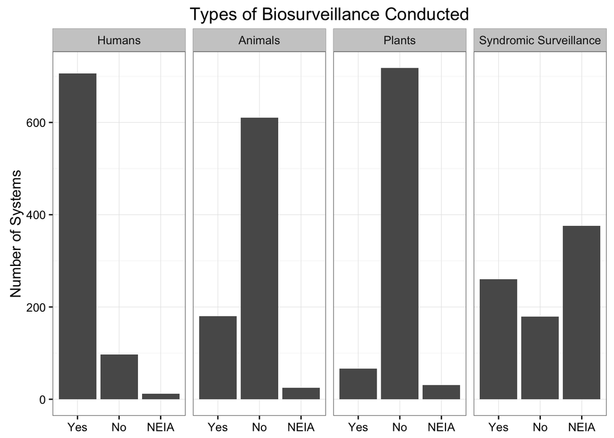

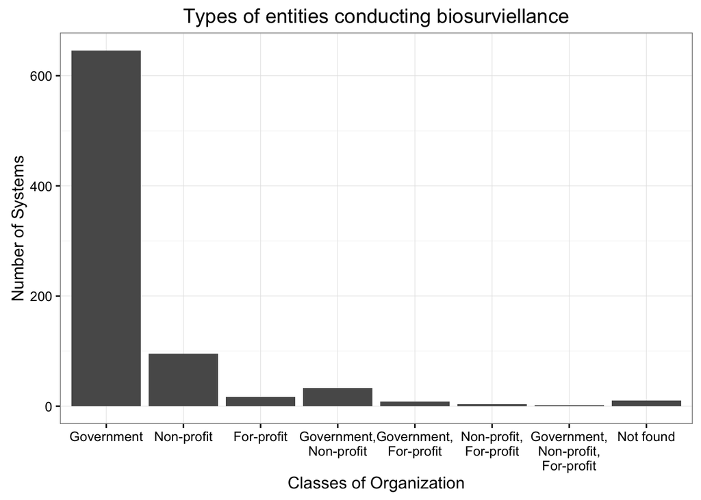

We examined data collected on surveillance system termination and creation. Of the 815 surveillance systems in the database, 682 have information on both year of creation and, unless currently active, year of termination. Surveillance system creation peaked in 2006, tailing off after 2009. Termination of active systems increased significantly after 2000, peaking in 2013. Accounting for system creation and termination, the largest concurrent number of active surveillance systems was 513, occurring in 2011.

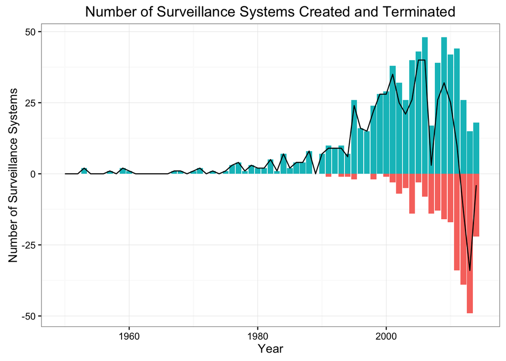

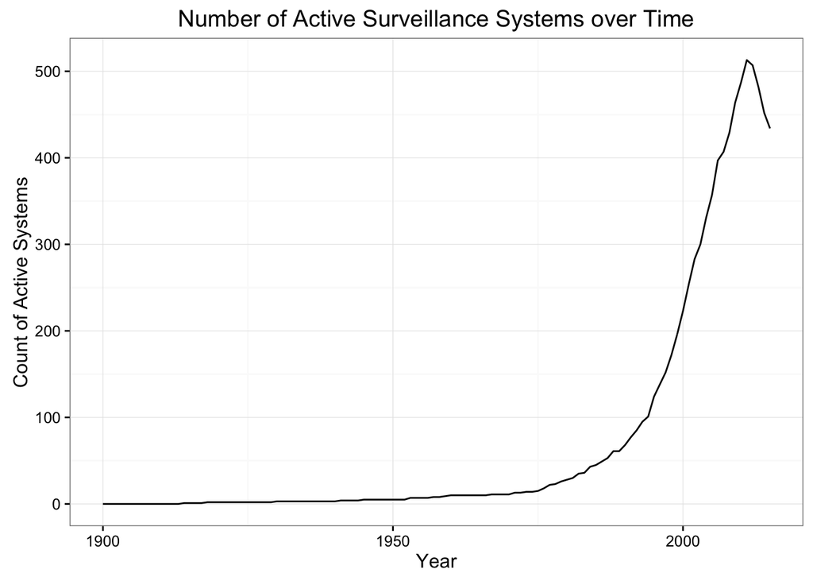

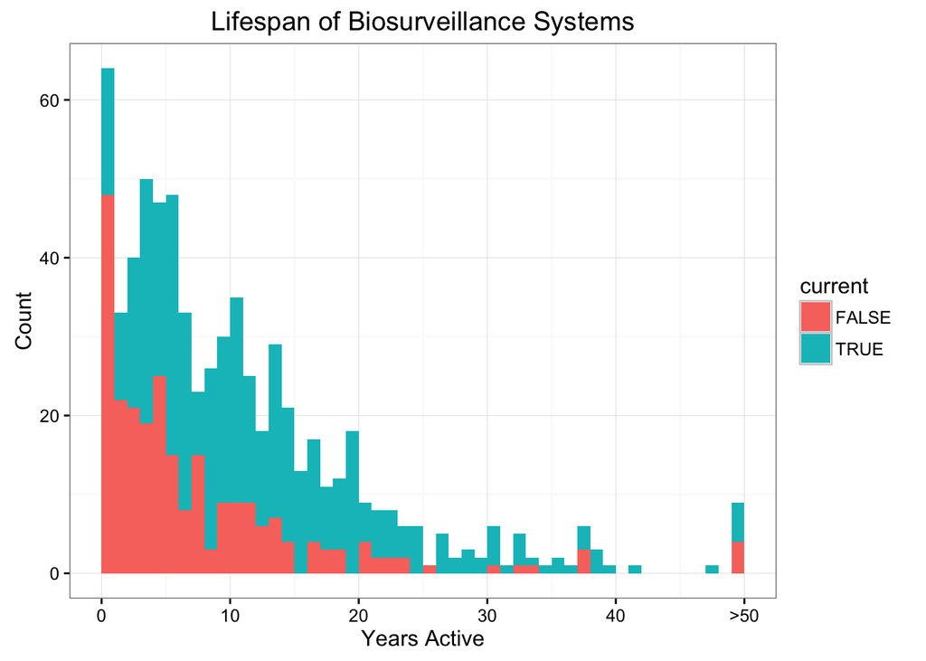

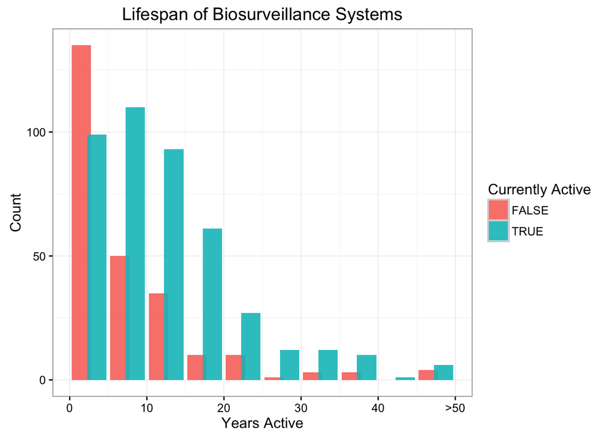

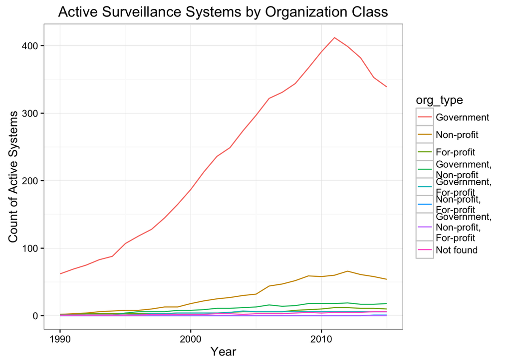

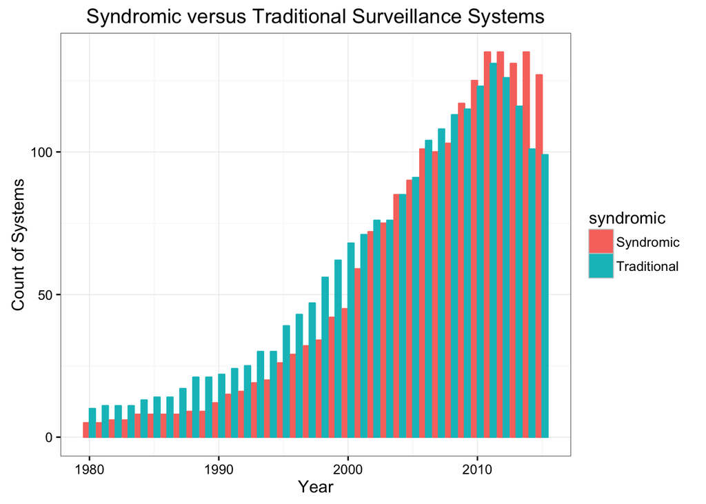

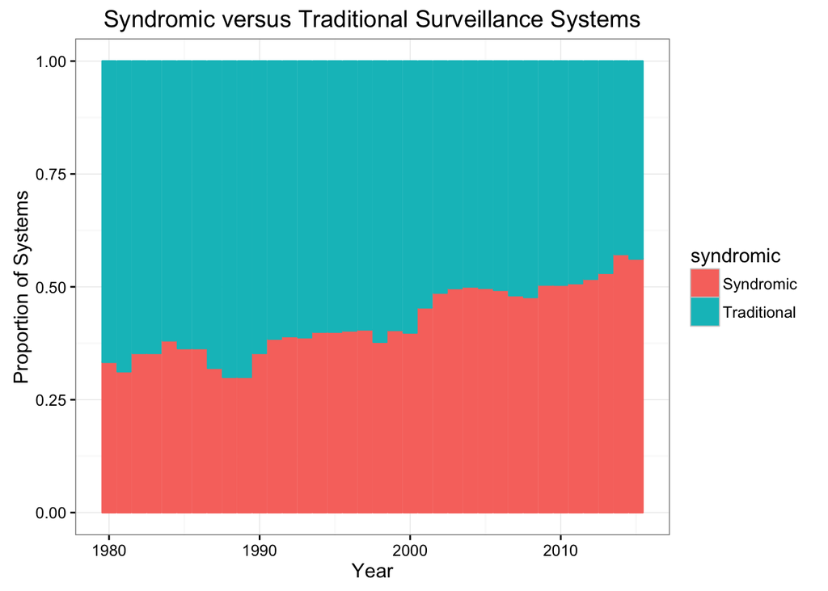

The United States was covered by the largest number of surveillane systems (290). However, the number of surveillance systems per country is not by itself a meaningful measure of surveillance effort, as the United States also covers a larger area and a larger population than many other countries. Plotting the number of surveillance systems per capita for each country shows a different aspect of surveillance system distribution.

```
## 189 codes from your data successfully matched countries in the map
## 0 codes from your data failed to match with a country code in the map
## 55 codes from the map weren't represented in your data
```

[output not shown]

[output cut: 20 more lines]

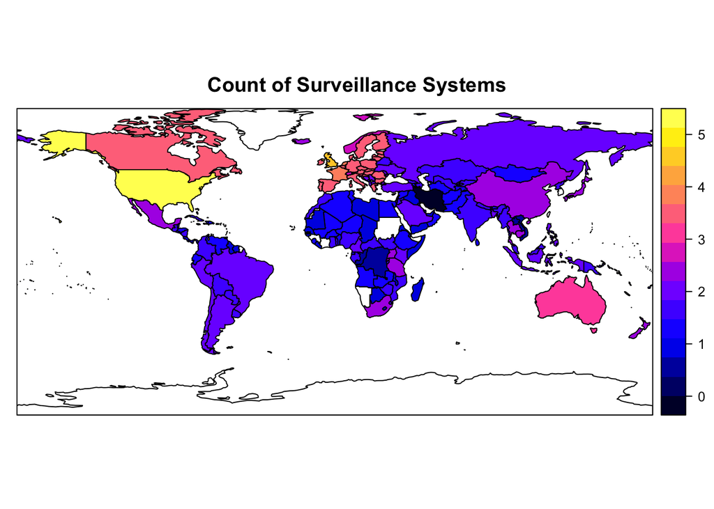

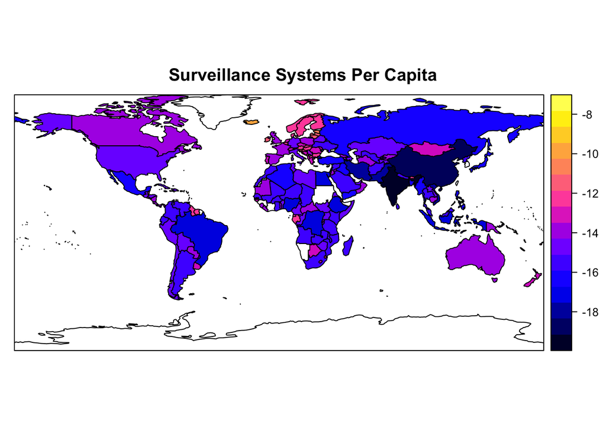

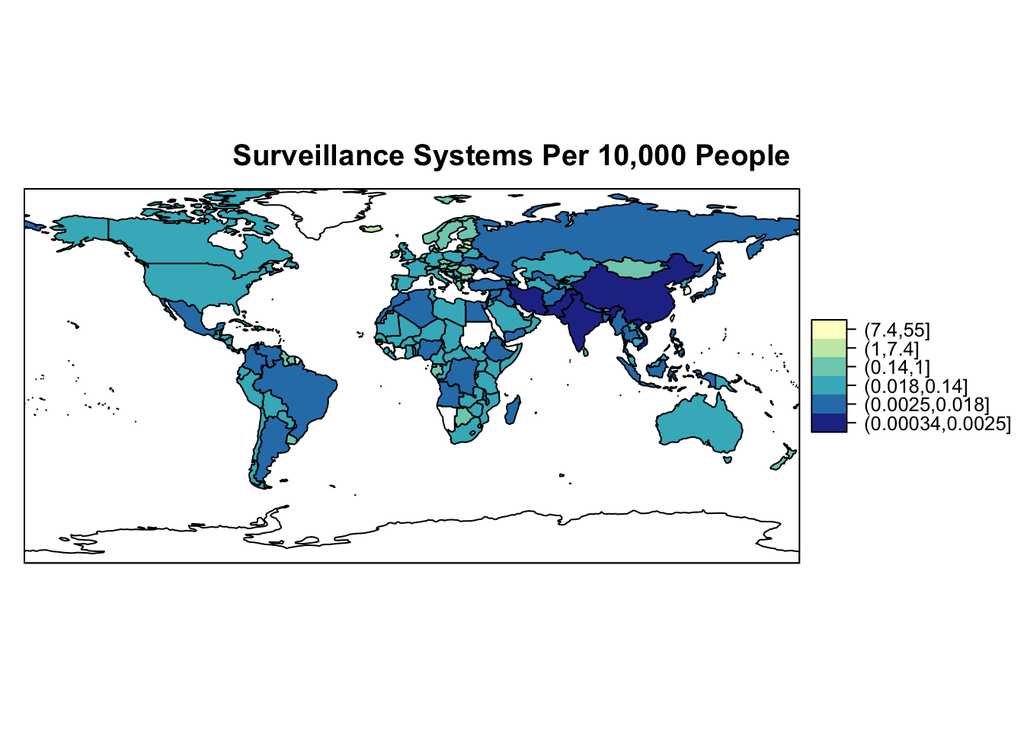

## One Health analysis

|  | humans | animals | plants | humans_only | animals_only | plants_only | ha | pa | hap |
| --- | --- | --- | --- | --- | --- | --- | --- | --- | --- |
|  | Mode :logical | Mode :logical | Mode :logical | Mode :logical | Mode :logical | Mode :logical | Mode :logical | Mode :logical | Mode :logical |
|  | FALSE:97 | FALSE:610 | FALSE:718 | FALSE:205 | FALSE:746 | FALSE:788 | FALSE:685 | FALSE:736 | FALSE:754 |
|  | TRUE :706 | TRUE :180 | TRUE :66 | TRUE :585 | TRUE :57 | TRUE :14 | TRUE :105 | TRUE :49 | TRUE :31 |
|  | NA’s :12 | NA’s :25 | NA’s :31 | NA’s :25 | NA’s :12 | NA’s :13 | NA’s :25 | NA’s :30 | NA’s :30 |

|  | humans | animals | plants | humans_only | animals_only | plants_only | ha | pa | hap |
| --- | --- | --- | --- | --- | --- | --- | --- | --- | --- |
|  | Mode :logical | Mode :logical | Mode :logical | Mode :logical | Mode :logical | Mode :logical | Mode :logical | Mode :logical | Mode :logical |
|  | FALSE:109 | FALSE:635 | FALSE:749 | FALSE:217 | FALSE:758 | FALSE:801 | FALSE:710 | FALSE:766 | FALSE:784 |
|  | TRUE :706 | TRUE :180 | TRUE :66 | TRUE :598 | TRUE :57 | TRUE :14 | TRUE :105 | TRUE :49 | TRUE :31 |
|  | NA’s :0 | NA’s :0 | NA’s :0 | NA’s :0 | NA’s :0 | NA’s :0 | NA’s :0 | NA’s :0 | NA’s :0 |

| ISO3 | systems_per_100000 |
| --- | --- |
| TUV | 40.4285426 |
| PLW | 18.9600417 |
| SMR | 15.8042798 |
| MCO | 10.5080649 |
| MHL | 7.5797772 |
| AND | 7.4856836 |
| MLT | 6.3172081 |
| KNA | 5.4755517 |
| LUX | 4.8554689 |
| DMA | 4.1470259 |
| KIR | 3.8483000 |
| TON | 3.7813617 |
| ISL | 3.6631267 |
| ATG | 3.3002211 |
| SYC | 3.2777571 |
| GRD | 2.8221217 |
| VCT | 2.7429575 |
| CYP | 2.4283254 |
| EST | 2.2075979 |
| WSM | 2.0851687 |
| FSM | 1.9248722 |
| LCA | 1.6340047 |
| VUT | 1.5485809 |
| STP | 1.5160550 |
| LVA | 1.4570294 |
| SVN | 1.4062529 |
| BRB | 1.0487090 |
| LTU | 0.9899898 |
| MNE | 0.9649405 |
| BRN | 0.9451684 |

[output cut: 214 more lines]